# cellhashR Example

2020-12-15

```r
library(cellhashR)

knitr::opts_chunk$set(message=FALSE, warning=FALSE, echo=TRUE, error=TRUE)

knitr::opts_knit$set(root.dir = '/Projects/cellhashR')
```

# Library Saturation

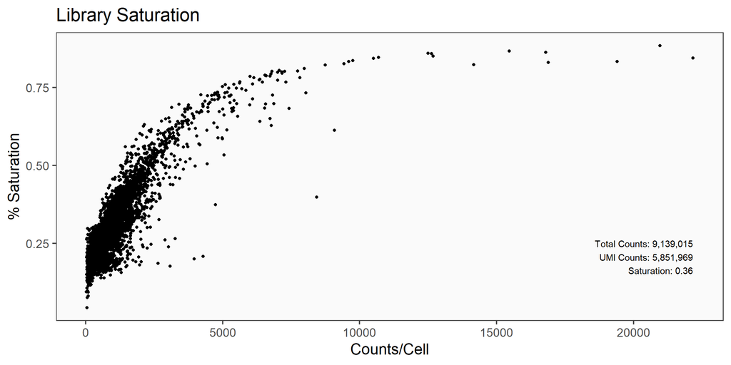

```r
saturation <- cellhashR:::PlotLibrarySaturation('./tests/testdata/438-21-GEX')
```

# Data Loading / QC:

```r
barcodeDir <- './tests/testdata/cellHashing/247-1-hashTagCounts.txt'

barcodeData <- ProcessCountMatrix(rawCountData = barcodeDir, minCountPerCell = 5)
```

```
## [1] "Initial cell barcodes in hashing data: 10400"
```

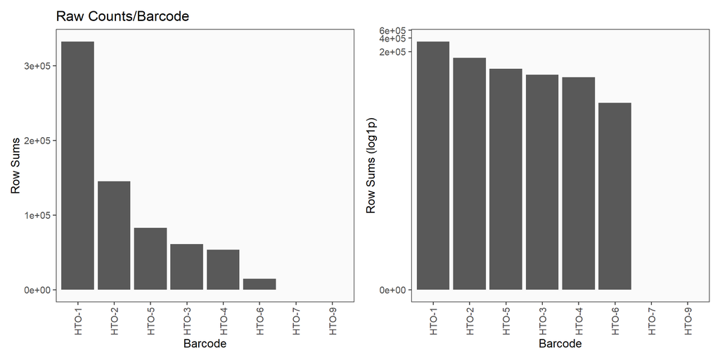

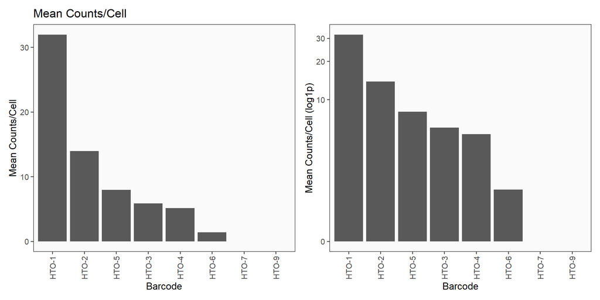

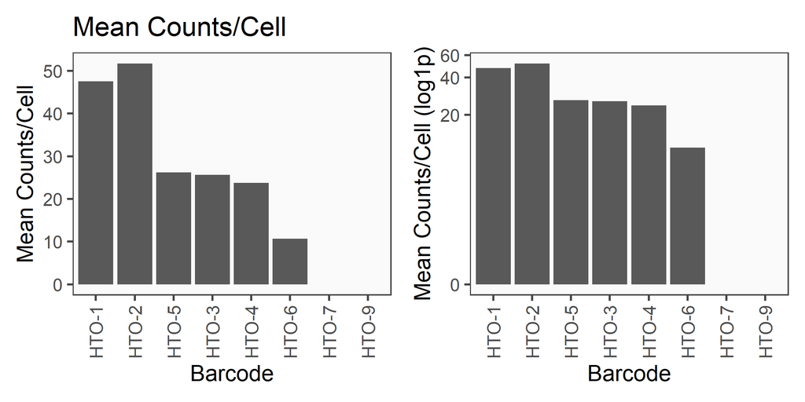

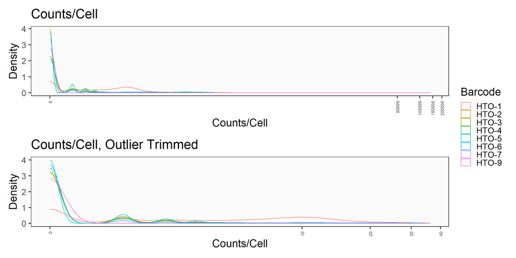

```
## [1] "Cells dropped due to low total counts per cell (<5): 1837"
## [1] "After filter: 8563"
```

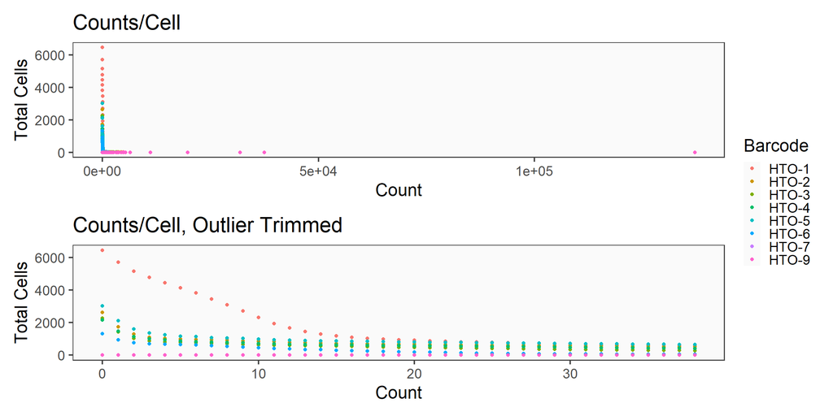

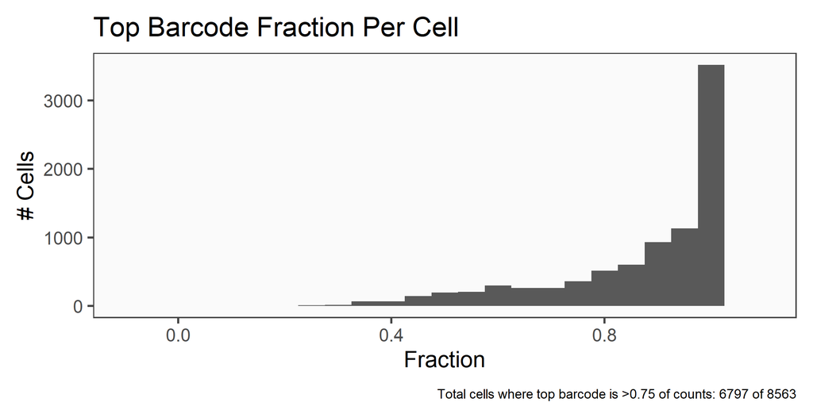

```r
if (nrow(barcodeData) == 0) {
  print('No passing barcodes')
}

if (ncol(barcodeData) == 0) {
  print('No passing cells')
}
```

# Data Loading / QC Using Barcode Whitelist:

This is identical to above, except we provide a whitelist of the expected barcodes, which will be used to subset data. This is a more realistic usage example.

```r
saveOriginalCellBarcodeFile <- 'originalBarcodes.txt'
barcodeData <- ProcessCountMatrix(rawCountData = barcodeDir, minCountPerCell = 5, barcodeWhitelist = c('HTO-1', 'HTO-2', 'HTO-3', 'HTO-4', 'HTO-6'), saveOriginalCellBarcodeFile = saveOriginalCellBarcodeFile)
```

```
## [1] "Initial cell barcodes in hashing data: 10400"
```

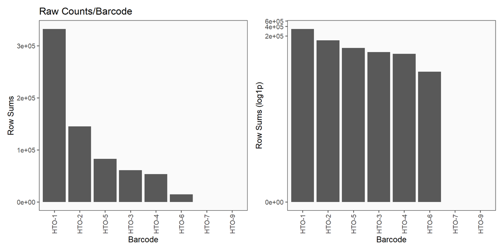

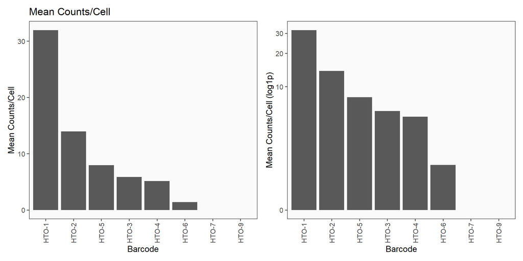

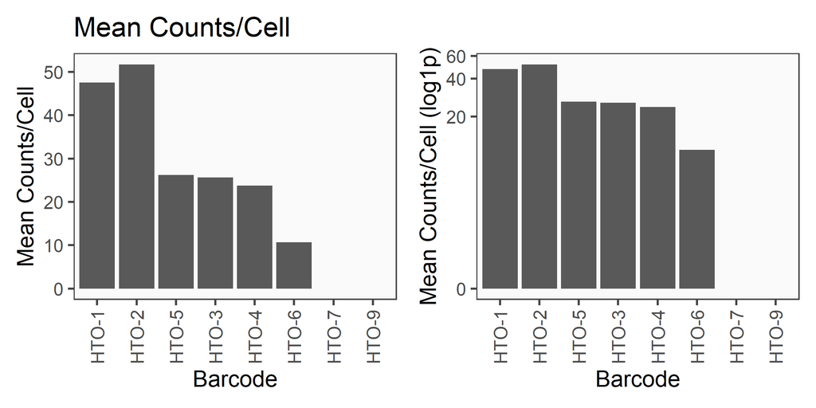

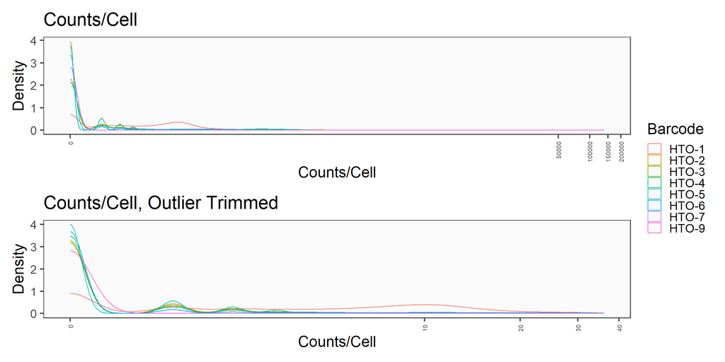

```
## [1] "Limiting to barcodes: HTO-1,HTO-2,HTO-3,HTO-4,HTO-6"
## [1] "Cells dropped due to low total counts per cell (<5): 2765"
## [1] "After filter: 7635"
```

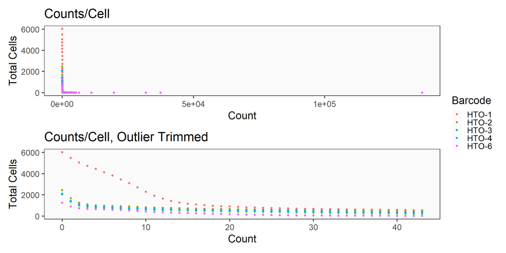

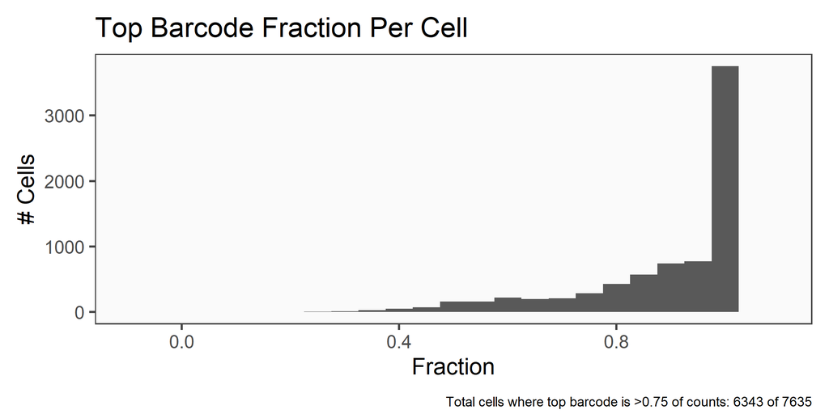

```r
if (nrow(barcodeData) == 0) {
  print('No passing barcodes')
}

if (ncol(barcodeData) == 0) {
  print('No passing cells')
}
```

# Normalization / QC

These plots are designed to provide visualization of potential normalizations.

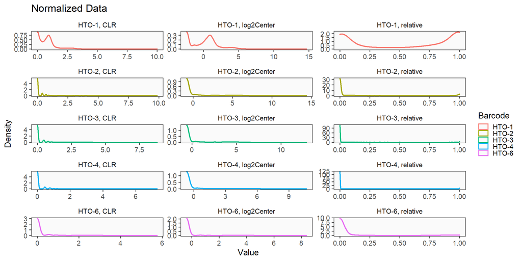

```
## [1] "Running tSNE with perplexity: 100 for normalization: log2Center"
```

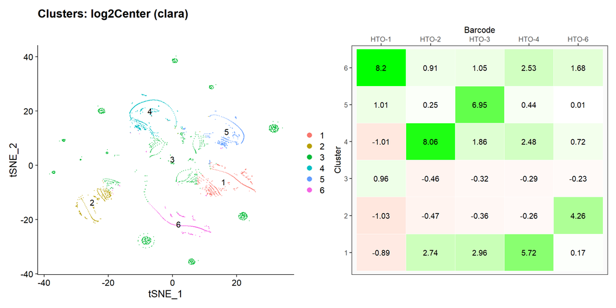

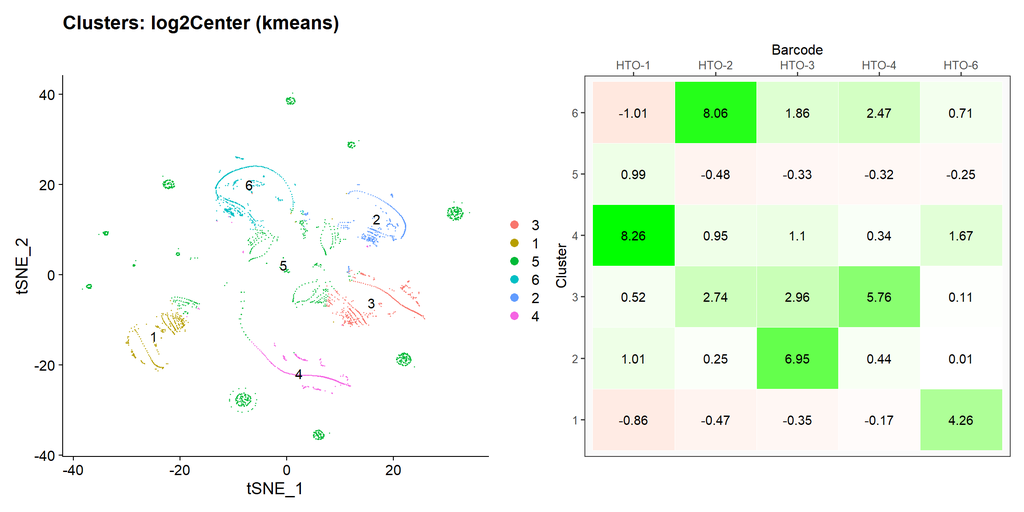

```
## [1] "Running tSNE with perplexity: 100 for normalization: CLR"
```

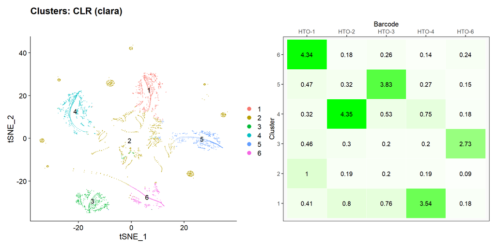

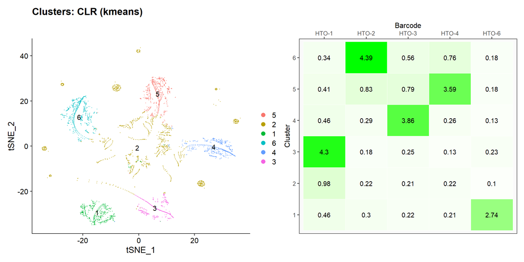

```
## [1] "Running tSNE with perplexity: 100 for normalization: relative"
```

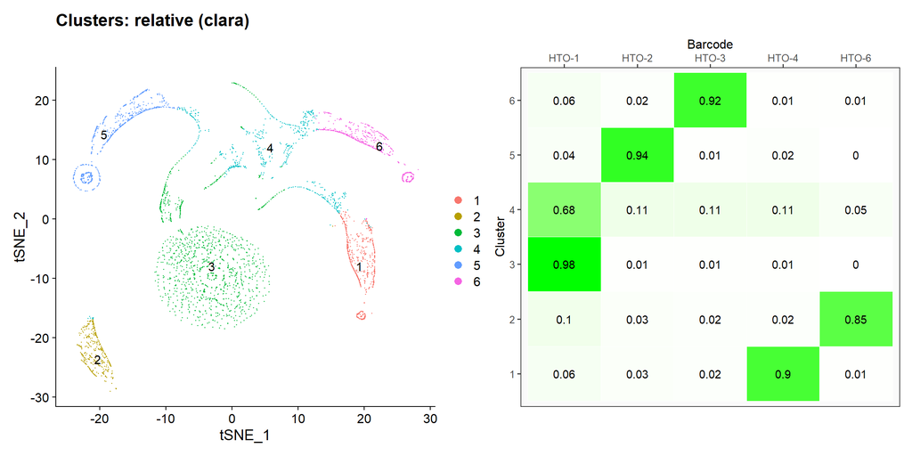

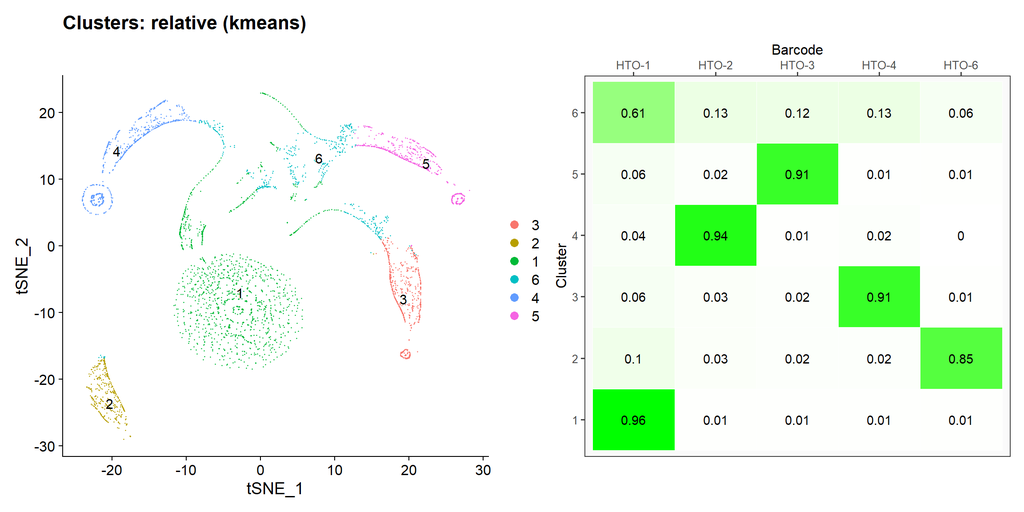

```r
PlotNormalizationQC(barcodeData)
```

# Generate Hashing Calls

The actual hashing calls are generated below. One or more calling algorithms can be used. If multiple algorithms are selected, the consensus call is used, which is the union of all non-negative calls. Any discordant call is marked as such.

Note: if you provide a vector of expected barcodes (such as all barcodes with passing gene expresison data), the plots will include these in the summary. This is useful to evaluate whether cells were dropped due to lack of cell hashing counts, as opposed to uncallable for other reasons.

```r
if (nrow(barcodeData) > 0 && ncol(barcodeData) > 0){

    cellbarcodeWhitelist <- read.table(saveOriginalCellBarcodeFile, header = FALSE, col.names = c('cellbarcode'))
    df <- GenerateCellHashingCalls(barcodeMatrix = barcodeData, methods = c('multiseq', 'htodemux'), cellbarcodeWhitelist = cellbarcodeWhitelist$cellbarcode)
} else {
    stop('No passing cels were found in the count matrix')
}
```

```
## [1] "Starting Multiseq deMULTIplex"
```

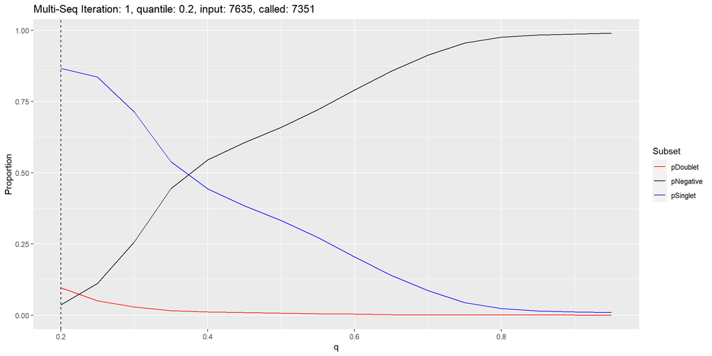

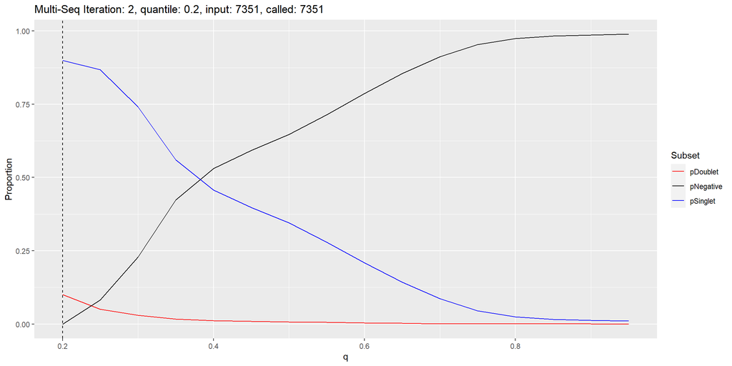

```
## [1] "no negatives, breaking after iteration: 2"
```

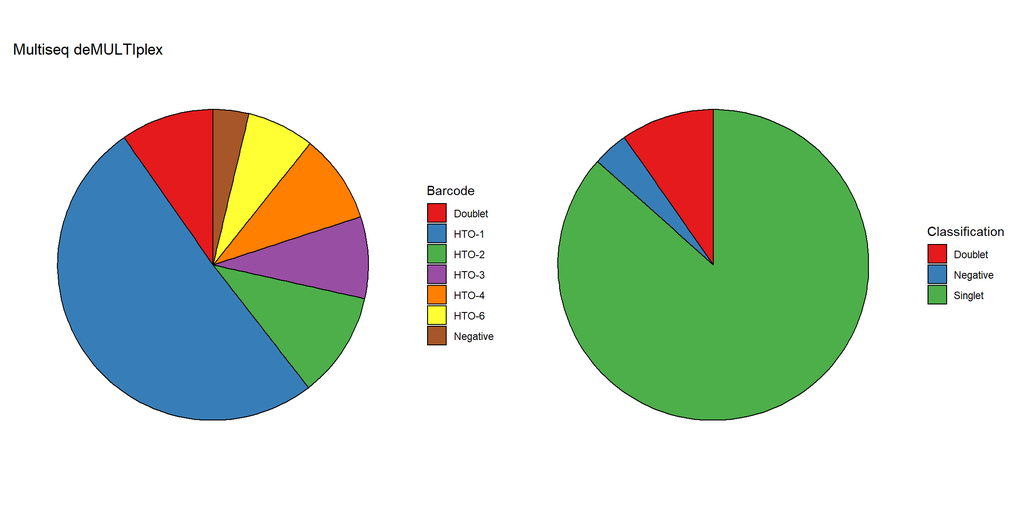

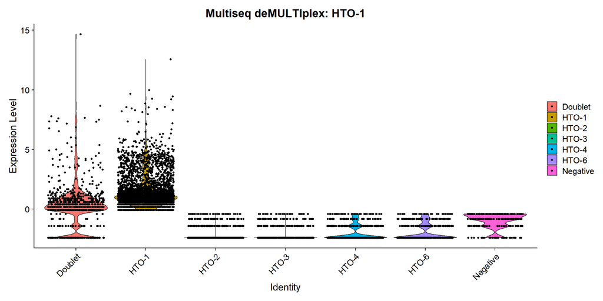

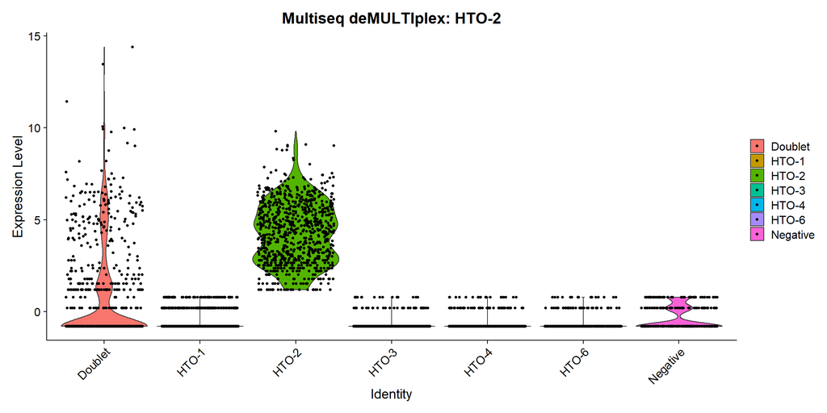

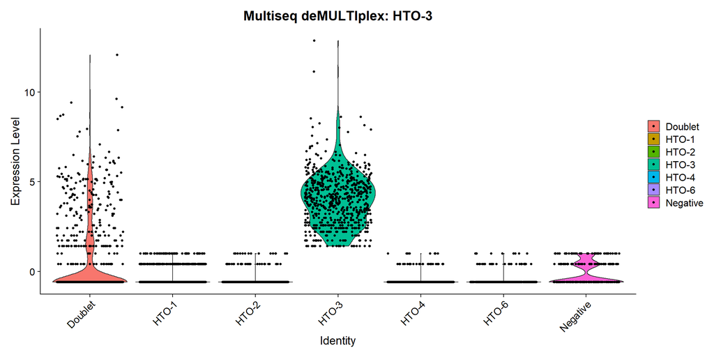

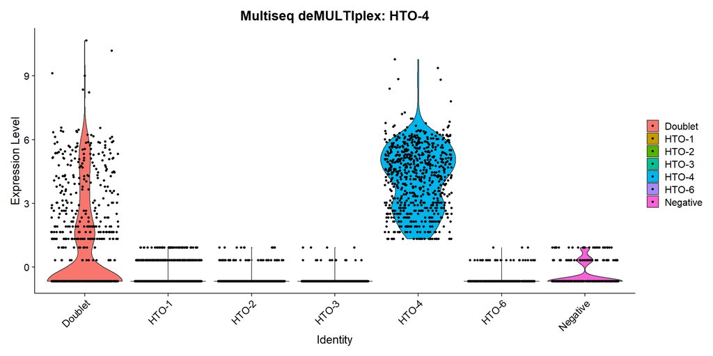

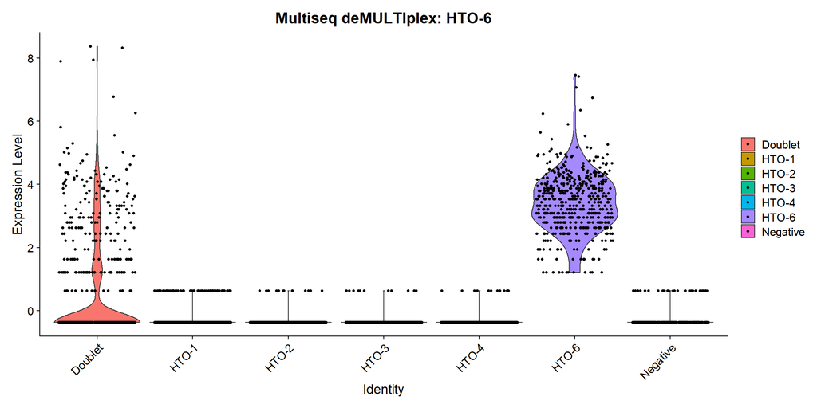

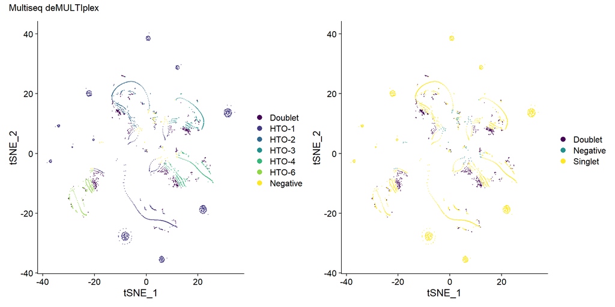

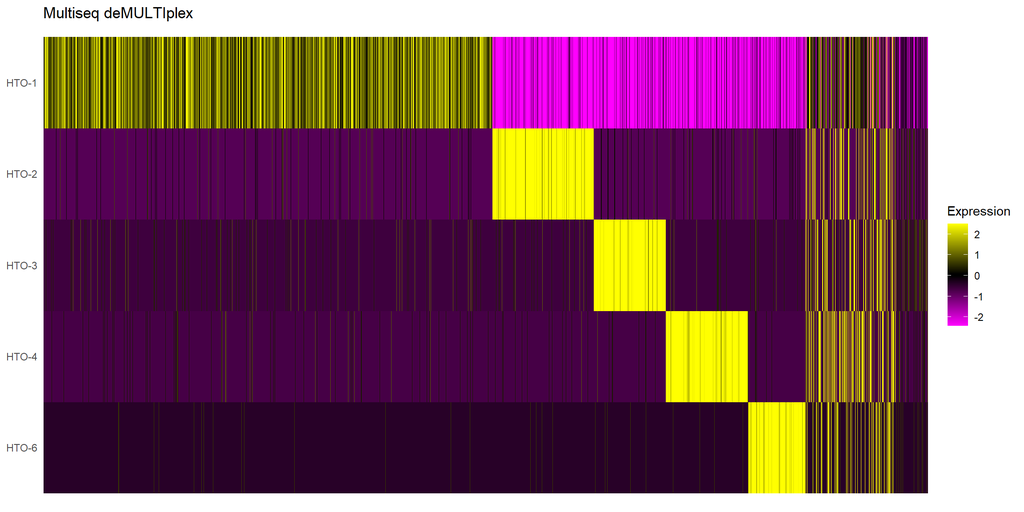

```
## [1] "Starting HTODemux"
## [1] "Will select bottom 2 barcodes as background"
## [1] "Background clusters for HTO-1: 4,1"
## [1] "total cells for background: 1775"
## [1] "Cutoff for HTO-1 : 14 reads"
## [1] "Will select bottom 2 barcodes as background"
## [1] "Background clusters for HTO-2: 6,2"
## [1] "total cells for background: 4451"
## [1] "Cutoff for HTO-2 : 2 reads"
## [1] "Will select bottom 2 barcodes as background"
## [1] "Background clusters for HTO-3: 3,2"
## [1] "total cells for background: 4517"
## [1] "Cutoff for HTO-3 : 2 reads"
## [1] "Will select bottom 2 barcodes as background"
## [1] "Background clusters for HTO-4: 6,2"
## [1] "total cells for background: 4451"
## [1] "Cutoff for HTO-4 : 2 reads"
## [1] "Will select bottom 2 barcodes as background"
## [1] "Background clusters for HTO-6: 2,5"
## [1] "total cells for background: 4596"
## [1] "Cutoff for HTO-6 : 1 reads"
```